# Assignment, week 2: California housing

The objective of this assignment was to train a fully connected neural network model to predict the median housing prices in California. The plan was to first build a model that is prone to overfitting, and then trying out different ways of reducing the overfitting. The main parameter to focus on here was mean average error.

## Data and imports

First I imported the necessary libraries and downloaded the dataset. I split the dataset to training and test sets, with 20% reserved for testing the model. The training set was further divided into parts for training and validating the model.

```python
import numpy as np
import matplotlib.pyplot as plt
from keras.models import Sequential
from keras.layers import Input, Dense
from keras.datasets import california_housing
from keras.callbacks import EarlyStopping

from sklearn.model_selection import train_test_split

# Download training and test sets
(inputs, targets), (x_test, y_test) = california_housing.load_data(version='large', test_split=0.2)

# Split into training and validation
x_train, x_val, y_train, y_val = train_test_split(
    inputs, targets, test_size=0.2, random_state=13
)

print(x_train.shape, y_train.shape)
print(x_val.shape, y_val.shape)
print(x_test.shape, y_test.shape)
```

```
(13209, 8) (13209,)
(3303, 8) (3303,)
(4128, 8) (4128,)
```

The input features needed to be standardized according to the training set. The target variable (house price) was divided by 100 000.

```python
mean = x_train.mean(axis=0)
std = x_train.std(axis=0)

x_train -= mean
x_train /= std
x_test -= mean
x_test /= std
x_val -= mean
x_val /= std

y_train /= 1e5
y_test /= 1e5
y_val /= 1e5
```

## Creating the first model

Here I created the first model. The aim here was to create a model that is prone to overfitting, so that I could later modify it to reduce the overfitting.

The baseline model was simple, made of Input layer, two Dense layers, and an output layer. I used Adam optimizer with no modifiers.

The model was trained for full 500 epochs, with batch size 32.

```python
# Model architecture
model = Sequential([
    Input(shape=(8,)),
    Dense(64, activation='relu'),
    Dense(64, activation='relu'),
    Dense(1)
])

# Compile model with Adam optimizer
model.compile(optimizer='adam',loss='mse',metrics=['mae'])

# Training the model
history = model.fit(x_train, y_train, epochs=500, batch_size=32, validation_data=(x_val, y_val), verbose=0)
```

After the model was trained, I plotted the loss values for training set and validation set.

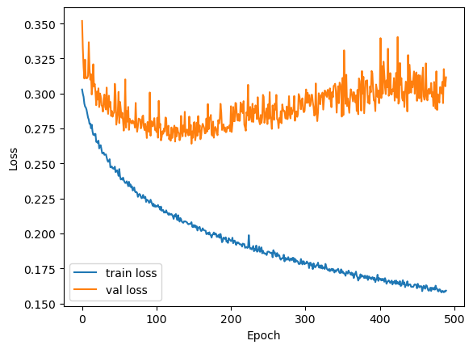

```python
plt.plot(history.history['loss'][10:], label='train loss')
plt.plot(history.history['val_loss'][10:], label='val loss')
plt.legend()
plt.xlabel('Epoch')
plt.ylabel('Loss')
```

Next I printed the plots for mean absolute error:

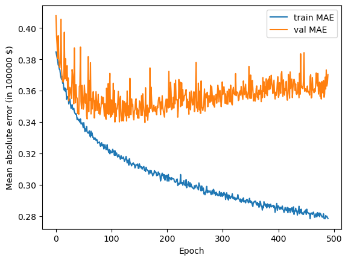

```python
plt.plot(history.history['mae'][10:], label='train MAE')
plt.plot(history.history['val_mae'][10:], label='val MAE')
plt.legend()
plt.xlabel('Epoch')
plt.ylabel('Mean absolute error (in 100000 $)')
```

The overfitting can be seen here as well.

Finally, I printed out the training and validation loss and mae for this model to later compare with the modified model.

```python
print("Final training MAE:", history.history['mae'][-1])
print("Final training loss:", history.history['loss'][-1])

print("Final validation MAE:", history.history['val_mae'][-1])
print("Final validation loss:", history.history['val_loss'][-1])
```

```
Final training MAE: 0.27856624126434326
Final training loss: 0.15917076170444489
Final validation MAE: 0.37025144696235657
Final validation loss: 0.3116053640842438
```

## Optimizing the model

First I got a baseline MAE value from the mean value of targets in training set.

```python
from keras.losses import MeanAbsoluteError

y_pred_baseline = np.full_like(y_test, np.mean(y_train, axis=0))
mae_fn = MeanAbsoluteError()
mae_baseline = mae_fn(y_test, y_pred_baseline).numpy()
print(f'Mean baseline MAE: {mae_baseline:.4f}')
```

```
Mean baseline MAE: 0.9067
```

Here I started building the optimized model. The new model is organized into three batches, each containing a Dense layer with added L2 regularizer to manage weights, BatchNormalization to balance layers, and Dropout to prevent memorization. Two batches have 64 units, and the third has 32 units. I tweaked around with the regularizer values, and the Dropout amounts to find the optimal for low MAE values in the end.

```python
from keras.regularizers import l2
from keras.layers import Dropout, BatchNormalization, Activation

# Model architecture
model = Sequential([

    # Input layer for 8 parameters
    Input(shape=(8,)),

    # Batch 1
    Dense(64, kernel_regularizer=l2(0.0005)),
    BatchNormalization(),
    Activation('relu'),
    Dropout(0.03),

    # Batch 2
    Dense(64, kernel_regularizer=l2(0.0005)),
    BatchNormalization(),
    Activation('relu'),
    Dropout(0.03),

    # Batch 3
    Dense(32, kernel_regularizer=l2(0.0005)),
    BatchNormalization(),
    Activation('relu'),
    Dropout(0.03),

    # Output layer with one unit
    Dense(1)
])
```

I also added callbacks. EarlyStopping will prevent overfitting by stopping the training when no more progress is happening. ReduceLROnPlateau reduces learning rate during training, improving the performance of the model.

```python
from keras.optimizers import Adam
from keras.callbacks import ReduceLROnPlateau

# Add early stopping to save resources
early_stopping = EarlyStopping(monitor='val_loss', patience=10, verbose=0, mode='auto', restore_best_weights=True)

# Add ReduceLROnPlateau callback to reduce learning rate during training
reduce_lr = ReduceLROnPlateau(monitor='val_loss', factor=0.5, patience=5, min_lr=1e-5)

# Add both callbacks to a list
callbacks = [early_stopping, reduce_lr]
```

The same Adam optimizer was used, but now the learning rate modifier is added.

```python
# Add learning rate modifier to the optimizer
model.compile(optimizer=Adam(learning_rate=0.001),loss='mse',metrics=['mae'])

# Training the model
history = model.fit(x_train, y_train, epochs=500, batch_size=64, validation_data=(x_val, y_val), callbacks=callbacks)
```

```
207/207 ━━━━━━━━━━━━━━━━━━━━ 7s 10ms/step - loss: 1.4889 - mae: 0.8519 - val_loss: 0.7685 - val_mae: 0.5835 - learning_rate: 0.0010
207/207 ━━━━━━━━━━━━━━━━━━━━ 2s 7ms/step - loss: 0.5612 - mae: 0.5159 - val_loss: 0.4633 - val_mae: 0.4227 - learning_rate: 0.0010
207/207 ━━━━━━━━━━━━━━━━━━━━ 2s 8ms/step - loss: 0.5235 - mae: 0.4948 - val_loss: 0.4164 - val_mae: 0.4108 - learning_rate: 0.0010
207/207 ━━━━━━━━━━━━━━━━━━━━ 2s 8ms/step - loss: 0.4863 - mae: 0.4748 - val_loss: 0.4270 - val_mae: 0.4120 - learning_rate: 0.0010
207/207 ━━━━━━━━━━━━━━━━━━━━ 2s 8ms/step - loss: 0.4781 - mae: 0.4660 - val_loss: 0.3981 - val_mae: 0.4010 - learning_rate: 0.0010
207/207 ━━━━━━━━━━━━━━━━━━━━ 2s 8ms/step - loss: 0.4638 - mae: 0.4594 - val_loss: 0.3894 - val_mae: 0.3855 - learning_rate: 0.0010
207/207 ━━━━━━━━━━━━━━━━━━━━ 2s 8ms/step - loss: 0.4498 - mae: 0.4510 - val_loss: 0.3867 - val_mae: 0.3769 - learning_rate: 0.0010
207/207 ━━━━━━━━━━━━━━━━━━━━ 2s 8ms/step - loss: 0.4418 - mae: 0.4459 - val_loss: 0.3811 - val_mae: 0.3827 - learning_rate: 0.0010
207/207 ━━━━━━━━━━━━━━━━━━━━ 2s 8ms/step - loss: 0.4371 - mae: 0.4448 - val_loss: 0.3852 - val_mae: 0.3903 - learning_rate: 0.0010
207/207 ━━━━━━━━━━━━━━━━━━━━ 2s 8ms/step - loss: 0.4315 - mae: 0.4403 - val_loss: 0.3752 - val_mae: 0.3788 - learning_rate: 0.0010
207/207 ━━━━━━━━━━━━━━━━━━━━ 1s 7ms/step - loss: 0.4245 - mae: 0.4341 - val_loss: 0.3721 - val_mae: 0.3913 - learning_rate: 0.0010
207/207 ━━━━━━━━━━━━━━━━━━━━ 1s 7ms/step - loss: 0.4078 - mae: 0.4282 - val_loss: 0.3671 - val_mae: 0.3729 - learning_rate: 0.0010
207/207 ━━━━━━━━━━━━━━━━━━━━ 1s 7ms/step - loss: 0.4128 - mae: 0.4266 - val_loss: 0.3826 - val_mae: 0.3886 - learning_rate: 0.0010
207/207 ━━━━━━━━━━━━━━━━━━━━ 1s 7ms/step - loss: 0.4122 - mae: 0.4307 - val_loss: 0.3598 - val_mae: 0.3749 - learning_rate: 0.0010
207/207 ━━━━━━━━━━━━━━━━━━━━ 1s 7ms/step - loss: 0.3998 - mae: 0.4221 - val_loss: 0.3542 - val_mae: 0.3629 - learning_rate: 0.0010
207/207 ━━━━━━━━━━━━━━━━━━━━ 1s 7ms/step - loss: 0.3987 - mae: 0.4220 - val_loss: 0.3522 - val_mae: 0.3742 - learning_rate: 0.0010
207/207 ━━━━━━━━━━━━━━━━━━━━ 1s 7ms/step - loss: 0.3933 - mae: 0.4208 - val_loss: 0.3617 - val_mae: 0.3828 - learning_rate: 0.0010
207/207 ━━━━━━━━━━━━━━━━━━━━ 1s 7ms/step - loss: 0.3854 - mae: 0.4149 - val_loss: 0.3477 - val_mae: 0.3664 - learning_rate: 0.0010
207/207 ━━━━━━━━━━━━━━━━━━━━ 1s 7ms/step - loss: 0.3928 - mae: 0.4191 - val_loss: 0.3473 - val_mae: 0.3652 - learning_rate: 0.0010
207/207 ━━━━━━━━━━━━━━━━━━━━ 1s 7ms/step - loss: 0.3766 - mae: 0.4122 - val_loss: 0.3446 - val_mae: 0.3636 - learning_rate: 0.0010
207/207 ━━━━━━━━━━━━━━━━━━━━ 1s 7ms/step - loss: 0.3860 - mae: 0.4175 - val_loss: 0.3510 - val_mae: 0.3844 - learning_rate: 0.0010
207/207 ━━━━━━━━━━━━━━━━━━━━ 1s 7ms/step - loss: 0.3825 - mae: 0.4156 - val_loss: 0.3515 - val_mae: 0.3825 - learning_rate: 0.0010
207/207 ━━━━━━━━━━━━━━━━━━━━ 1s 7ms/step - loss: 0.3771 - mae: 0.4136 - val_loss: 0.3455 - val_mae: 0.3726 - learning_rate: 0.0010
207/207 ━━━━━━━━━━━━━━━━━━━━ 2s 8ms/step - loss: 0.3736 - mae: 0.4113 - val_loss: 0.3307 - val_mae: 0.3636 - learning_rate: 0.0010
207/207 ━━━━━━━━━━━━━━━━━━━━ 2s 8ms/step - loss: 0.3682 - mae: 0.4059 - val_loss: 0.3386 - val_mae: 0.3717 - learning_rate: 0.0010
207/207 ━━━━━━━━━━━━━━━━━━━━ 2s 8ms/step - loss: 0.3639 - mae: 0.4045 - val_loss: 0.3382 - val_mae: 0.3627 - learning_rate: 0.0010
207/207 ━━━━━━━━━━━━━━━━━━━━ 2s 8ms/step - loss: 0.3714 - mae: 0.4072 - val_loss: 0.3331 - val_mae: 0.3757 - learning_rate: 0.0010
207/207 ━━━━━━━━━━━━━━━━━━━━ 2s 8ms/step - loss: 0.3615 - mae: 0.4053 - val_loss: 0.3410 - val_mae: 0.3634 - learning_rate: 0.0010
207/207 ━━━━━━━━━━━━━━━━━━━━ 2s 9ms/step - loss: 0.3665 - mae: 0.4061 - val_loss: 0.3403 - val_mae: 0.3808 - learning_rate: 0.0010
207/207 ━━━━━━━━━━━━━━━━━━━━ 2s 9ms/step - loss: 0.3493 - mae: 0.3980 - val_loss: 0.3239 - val_mae: 0.3575 - learning_rate: 5.0000e-04
207/207 ━━━━━━━━━━━━━━━━━━━━ 2s 8ms/step - loss: 0.3553 - mae: 0.4027 - val_loss: 0.3267 - val_mae: 0.3617 - learning_rate: 5.0000e-04
207/207 ━━━━━━━━━━━━━━━━━━━━ 2s 8ms/step - loss: 0.3531 - mae: 0.3997 - val_loss: 0.3205 - val_mae: 0.3489 - learning_rate: 5.0000e-04
207/207 ━━━━━━━━━━━━━━━━━━━━ 2s 9ms/step - loss: 0.3423 - mae: 0.3900 - val_loss: 0.3258 - val_mae: 0.3585 - learning_rate: 5.0000e-04
207/207 ━━━━━━━━━━━━━━━━━━━━ 2s 7ms/step - loss: 0.3488 - mae: 0.3978 - val_loss: 0.3261 - val_mae: 0.3654 - learning_rate: 5.0000e-04
207/207 ━━━━━━━━━━━━━━━━━━━━ 2s 7ms/step - loss: 0.3440 - mae: 0.3940 - val_loss: 0.3197 - val_mae: 0.3521 - learning_rate: 5.0000e-04
207/207 ━━━━━━━━━━━━━━━━━━━━ 1s 7ms/step - loss: 0.3444 - mae: 0.3942 - val_loss: 0.3154 - val_mae: 0.3552 - learning_rate: 5.0000e-04
207/207 ━━━━━━━━━━━━━━━━━━━━ 1s 6ms/step - loss: 0.3412 - mae: 0.3926 - val_loss: 0.3212 - val_mae: 0.3580 - learning_rate: 5.0000e-04
207/207 ━━━━━━━━━━━━━━━━━━━━ 1s 7ms/step - loss: 0.3390 - mae: 0.3918 - val_loss: 0.3221 - val_mae: 0.3544 - learning_rate: 5.0000e-04
207/207 ━━━━━━━━━━━━━━━━━━━━ 1s 7ms/step - loss: 0.3378 - mae: 0.3900 - val_loss: 0.3196 - val_mae: 0.3594 - learning_rate: 5.0000e-04
207/207 ━━━━━━━━━━━━━━━━━━━━ 2s 7ms/step - loss: 0.3354 - mae: 0.3886 - val_loss: 0.3145 - val_mae: 0.3573 - learning_rate: 5.0000e-04
```

[output cut: 86 more lines]

```
207/207 ━━━━━━━━━━━━━━━━━━━━ 1s 6ms/step - loss: 0.3037 - mae: 0.3737 - val_loss: 0.2888 - val_mae: 0.3389 - learning_rate: 1.0000e-05
207/207 ━━━━━━━━━━━━━━━━━━━━ 1s 7ms/step - loss: 0.3092 - mae: 0.3756 - val_loss: 0.2885 - val_mae: 0.3385 - learning_rate: 1.0000e-05
207/207 ━━━━━━━━━━━━━━━━━━━━ 2s 10ms/step - loss: 0.2981 - mae: 0.3701 - val_loss: 0.2888 - val_mae: 0.3385 - learning_rate: 1.0000e-05
207/207 ━━━━━━━━━━━━━━━━━━━━ 2s 12ms/step - loss: 0.3054 - mae: 0.3735 - val_loss: 0.2886 - val_mae: 0.3387 - learning_rate: 1.0000e-05
207/207 ━━━━━━━━━━━━━━━━━━━━ 3s 13ms/step - loss: 0.3061 - mae: 0.3735 - val_loss: 0.2881 - val_mae: 0.3377 - learning_rate: 1.0000e-05
207/207 ━━━━━━━━━━━━━━━━━━━━ 5s 11ms/step - loss: 0.3075 - mae: 0.3747 - val_loss: 0.2887 - val_mae: 0.3392 - learning_rate: 1.0000e-05
207/207 ━━━━━━━━━━━━━━━━━━━━ 2s 9ms/step - loss: 0.3035 - mae: 0.3717 - val_loss: 0.2889 - val_mae: 0.3401 - learning_rate: 1.0000e-05
207/207 ━━━━━━━━━━━━━━━━━━━━ 2s 8ms/step - loss: 0.3026 - mae: 0.3700 - val_loss: 0.2888 - val_mae: 0.3387 - learning_rate: 1.0000e-05
207/207 ━━━━━━━━━━━━━━━━━━━━ 2s 8ms/step - loss: 0.3022 - mae: 0.3728 - val_loss: 0.2889 - val_mae: 0.3394 - learning_rate: 1.0000e-05
207/207 ━━━━━━━━━━━━━━━━━━━━ 2s 10ms/step - loss: 0.3040 - mae: 0.3727 - val_loss: 0.2888 - val_mae: 0.3394 - learning_rate: 1.0000e-05
207/207 ━━━━━━━━━━━━━━━━━━━━ 1s 7ms/step - loss: 0.3012 - mae: 0.3728 - val_loss: 0.2888 - val_mae: 0.3389 - learning_rate: 1.0000e-05
207/207 ━━━━━━━━━━━━━━━━━━━━ 1s 6ms/step - loss: 0.3027 - mae: 0.3710 - val_loss: 0.2888 - val_mae: 0.3397 - learning_rate: 1.0000e-05
207/207 ━━━━━━━━━━━━━━━━━━━━ 1s 6ms/step - loss: 0.3063 - mae: 0.3735 - val_loss: 0.2889 - val_mae: 0.3391 - learning_rate: 1.0000e-05
207/207 ━━━━━━━━━━━━━━━━━━━━ 1s 6ms/step - loss: 0.3040 - mae: 0.3706 - val_loss: 0.2883 - val_mae: 0.3381 - learning_rate: 1.0000e-05
207/207 ━━━━━━━━━━━━━━━━━━━━ 1s 6ms/step - loss: 0.3027 - mae: 0.3728 - val_loss: 0.2883 - val_mae: 0.3379 - learning_rate: 1.0000e-05
```

Next I plotted the Loss curves for the training and validation data.

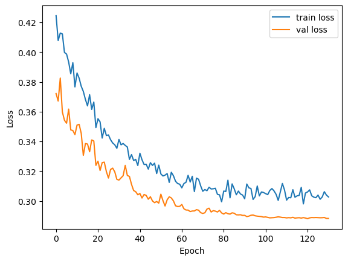

```python
plt.plot(history.history['loss'][10:], label='train loss')
plt.plot(history.history['val_loss'][10:], label='val loss')
plt.legend()
plt.xlabel('Epoch')
plt.ylabel('Loss')
```

From here we can see that this model performs well with the data, and it has low difference between the training and test sets. There also are no signs of overfitting.

Finally I plotted the curve for mean absolute error:

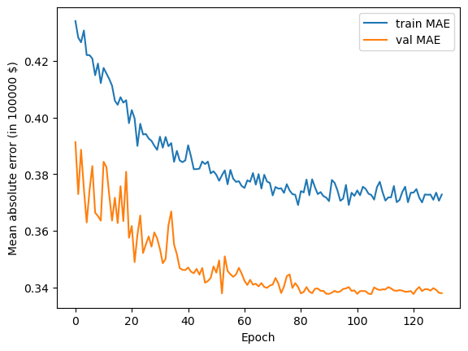

```python
plt.plot(history.history['mae'][10:], label='train MAE')
plt.plot(history.history['val_mae'][10:], label='val MAE')
plt.legend()
plt.xlabel('Epoch')
plt.ylabel('Mean absolute error (in 100000 $)')
```

Here again no visible signs of overfitting are present.

```python
# Training results
print("Final training MAE:", history.history['mae'][-1])
print("Final training loss:", history.history['loss'][-1])

# Validation results
print("Final validation MAE:", history.history['val_mae'][-1])
print("Final validation loss:", history.history['val_loss'][-1])
```

```
Final training MAE: 0.3728024661540985
Final training loss: 0.3027254343032837
Final validation MAE: 0.3379489481449127
Final validation loss: 0.28829801082611084
```

## Final testing of the model

Finally, the model was trained with the combined training and evaluation sets, and evaluates using the test set.

First I combined the sets to make the new full training set.

```python
# Combining the training and validation sets
x_train_full = np.concatenate((x_train, x_val), axis=0)
y_train_full = np.concatenate((y_train, y_val), axis=0)
```

The final model was trained using the full training set.

```python
# Model architecture matching the final model.
model = Sequential([

    Input(shape=(8,)),

    Dense(64, kernel_regularizer=l2(0.0005)),
    BatchNormalization(),
    Activation('relu'),
    Dropout(0.03),

    Dense(64, kernel_regularizer=l2(0.0005)),
    BatchNormalization(),
    Activation('relu'),
    Dropout(0.03),

    Dense(32, kernel_regularizer=l2(0.0005)),
    BatchNormalization(),
    Activation('relu'),
    Dropout(0.03),

    Dense(1)
])

# Same compling options as before.
model.compile(optimizer=Adam(learning_rate=0.001),loss='mse',metrics=['mae'])
```

The final training of the model is done without the EarlyStopping callback to be able to train the model with the full set of data. Instead, the epochs are limited to 140, which is close to what the last model needed.

```python
history = model.fit(x_train_full, y_train_full, epochs=140, batch_size=64, callbacks=[reduce_lr], verbose=0)
```

And lastly, the model was evaluated using the test data set.

```python
# Using the test sets to evaluate the model
test_loss, test_mae = model.evaluate(x_test, y_test, verbose=0)
print(f"Test MAE: {test_mae:.4f}, Test Loss: {test_loss:.4f}")
```

```
Test MAE: 0.3494, Test Loss: 0.2932
```

These final test results are close to the final validation results, which means that the final model works well with unseen data.